# Exercise Set 12 Solutions

ETC3550/ETC5550: 2021

# fpp3 10.7, Ex 2

> Repeat Exercise 4 from Section 7.10, but this time adding in ARIMA errors to address the autocorrelations in the residuals.
> 1. How much difference does the ARIMA error process make to the regression coefficients?

```r
fit <- souvenirs %>%
  mutate(festival = month(Month) == 3 & year(Month) != 1987) %>%
  model(
    reg = TSLM(log(Sales) ~ trend() + season() + festival),
    dynreg = ARIMA(log(Sales) ~ trend() + season() + festival)
  )
tidy(fit) %>% print(n=50)
```

```
## # A tibble: 31 x 6
##    .model term           estimate std.error statistic  p.value
##    <chr>  <chr>             <dbl>     <dbl>     <dbl>    <dbl>
##  1 reg    (Intercept)      7.62    0.0742     103.    4.67e-78
##  2 reg    trend()          0.0220  0.000827    26.6   2.32e-38
##  3 reg    season()year2    0.251   0.0957       2.63  1.06e- 2
##  4 reg    season()year3    0.266   0.193        1.38  1.73e- 1
##  5 reg    season()year4    0.384   0.0957       4.01  1.48e- 4
##  6 reg    season()year5    0.409   0.0957       4.28  5.88e- 5
##  7 reg    season()year6    0.449   0.0958       4.69  1.33e- 5
##  8 reg    season()year7    0.610   0.0958       6.37  1.71e- 8
##  9 reg    season()year8    0.588   0.0959       6.13  4.53e- 8
## 10 reg    season()year9    0.669   0.0959       6.98  1.36e- 9
## 11 reg    season()year10   0.747   0.0960       7.79  4.48e-11
## 12 reg    season()year11   1.21    0.0960      12.6   1.29e-19
```

[output cut: 19 more lines]

The coefficients are all relatively close.

> 2. How much difference does the ARIMA error process make to the forecasts?

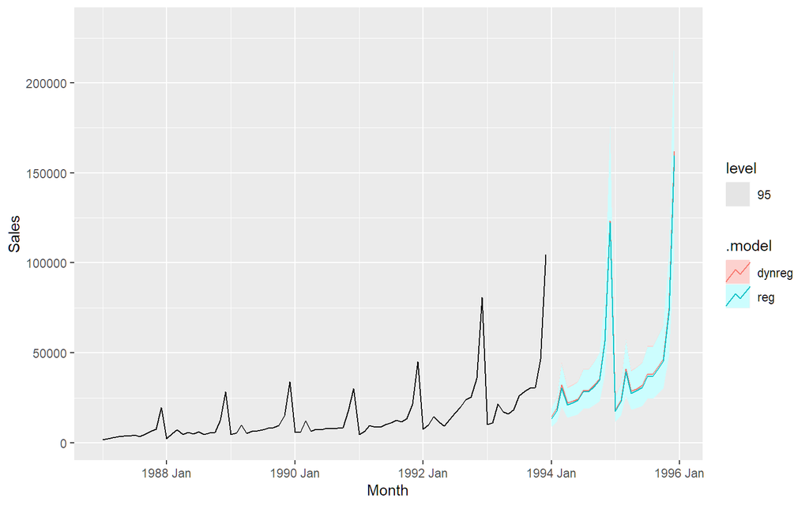

```r
future_souvenirs <- new_data(souvenirs, n = 24) %>%
  mutate(festival = month(Month) == 3)
fit %>%
  forecast(new_data = future_souvenirs)  %>%
  autoplot(souvenirs, level=95)
```

The forecasts are also extremely close.

> 3. Check the residuals of the fitted model to ensure the ARIMA process has adequately addressed the autocorrelations seen in the `TSLM` model.

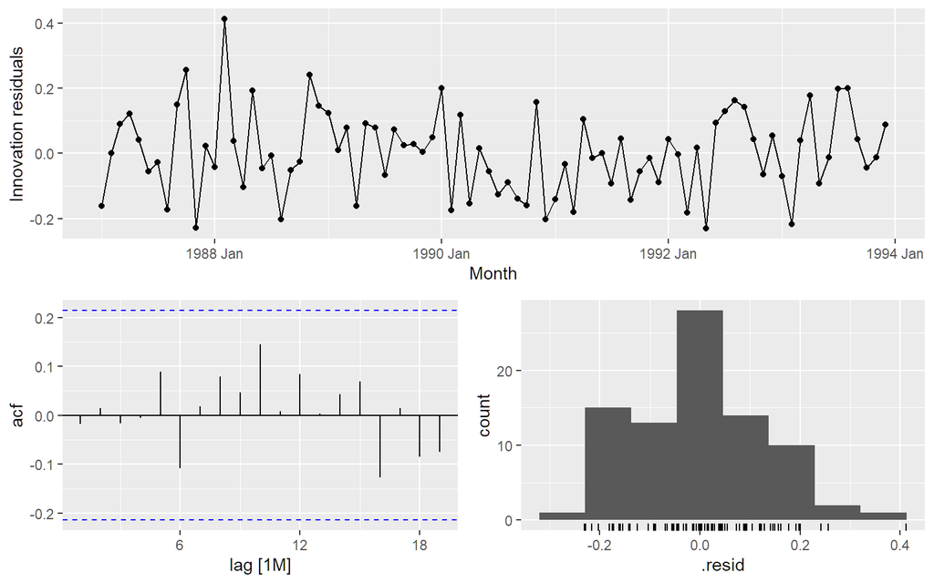

```r
fit %>%
  select(dynreg) %>%
  gg_tsresiduals()
```

These look fine.

# fpp3 10.7, Ex 3

> Repeat the daily electricity example, but instead of using a quadratic function of temperature, use a piecewise linear function with the “knot” around 25 degrees Celsius (use predictors `Temperature` & `Temp2`). How can you optimize the choice of knot?

```r
vic_elec_daily <- vic_elec %>%
  filter(year(Time) == 2014) %>%
  index_by(Date = date(Time)) %>%
  summarise(
    Demand = sum(Demand) / 1e3,
    Temperature = max(Temperature),
    Holiday = any(Holiday)
  ) %>%
  mutate(
    Temp2 = I(pmax(Temperature - 25, 0)),
    Day_Type = case_when(
      Holiday ~ "Holiday",
      wday(Date) %in% 2:6 ~ "Weekday",
      TRUE ~ "Weekend"
    )
  )
```

First, we will leave the knot at 25 and find the best ARIMA model. This will take a while, but we only have to do it once.

```r
vic_elec_daily %>%
  model(
    fit = ARIMA(Demand ~ Temperature + Temp2 + (Day_Type == "Weekday"),
      approximation = FALSE, stepwise = FALSE,
      order_constraint = p + q + P + Q <= 10
    )
  ) %>%
  report()
```

[output not shown]

```r
elec_model <- vic_elec_daily %>%
  mutate(Temp2 = I(pmax(Temperature - 28.4, 0))) %>%
  model(
    fit = ARIMA(Demand ~ Temperature + Temp2 + (Day_Type == "Weekday") +
      pdq(5, 1, 2) + PDQ(2, 0, 0),
    approximation = FALSE, order_constraint = p + q + P + Q <= 10
    )
  )
glance(elec_model) %>% pull(AICc)
```

```
##     week
## 2528.041
```

The optimal knot (to 1 decimal place) is 28.4 degrees Celsius.

```r
report(elec_model)
```

```
## Series: Demand
## Model: LM w/ ARIMA(5,1,2)(2,0,0)[7] errors
##
## Coefficients:
##          ar1     ar2     ar3      ar4     ar5      ma1      ma2    sar1    sar2
##       0.3078  0.3770  0.0517  -0.1440  0.1526  -0.5134  -0.4502  0.1697  0.3211
## s.e.  0.2106  0.1558  0.0631   0.0602  0.0636   0.2067   0.1945  0.0596  0.0564
##       Temperature   Temp2  Day_Type == "Weekday"TRUE
##            0.0782  5.3544                    31.0524
## s.e.       0.1345  0.3389                     1.2819
##
## sigma^2 estimated as 57.99:  log likelihood=-1250.5
## AIC=2527   AICc=2528.04   BIC=2577.66
```

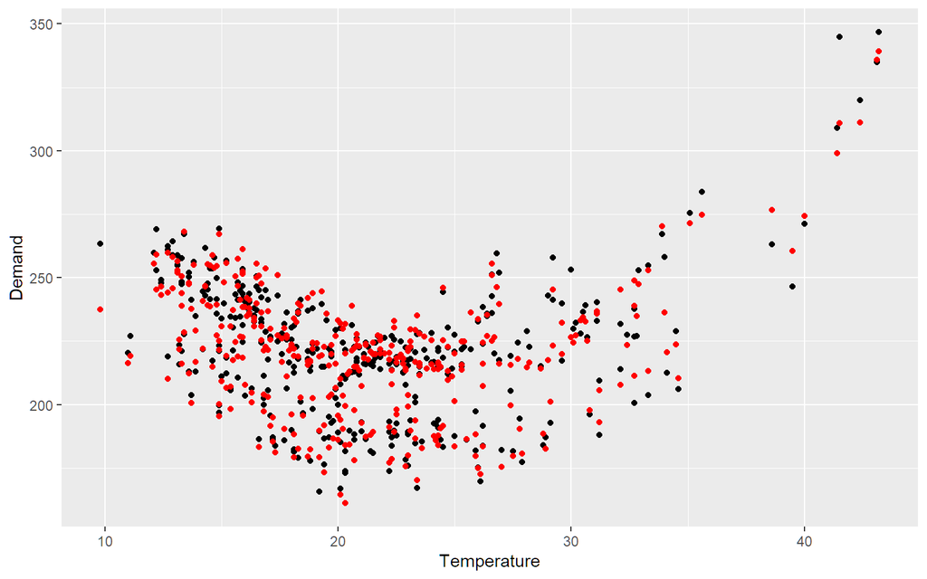

```r
augment(elec_model) %>%
  left_join(vic_elec_daily) %>%
  ggplot(aes(x = Temperature)) +
  geom_point(aes(y = Demand)) +
  geom_point(aes(y = .fitted), col = "red")
```

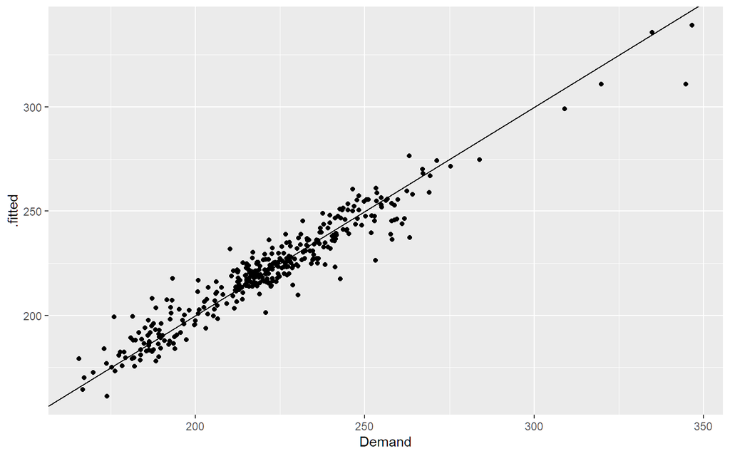

```r
augment(elec_model) %>%
  left_join(vic_elec_daily) %>%
  ggplot(aes(x = Demand)) +
  geom_point(aes(y = .fitted)) +
  geom_abline(aes(intercept = 0, slope = 1))
```

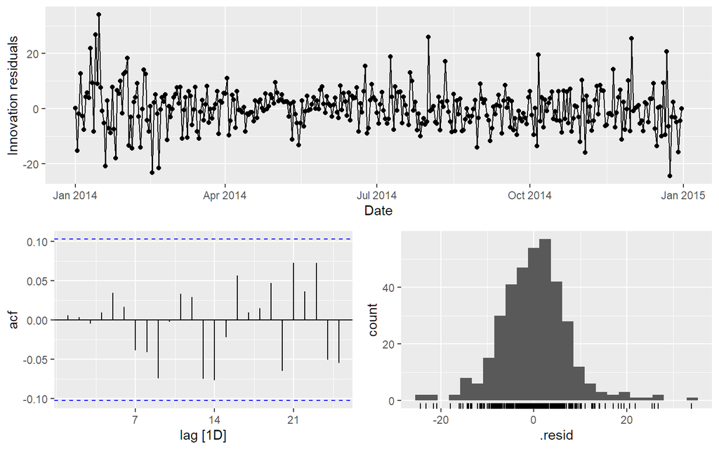

```r
elec_model %>% gg_tsresiduals()
```

```r
augment(elec_model) %>%
  features(.innov, ljung_box, dof = 12, lag = 21)
```

```
## # A tibble: 1 x 3
##   .model lb_stat lb_pvalue
##   <chr>    <dbl>     <dbl>
## 1 fit       15.1    0.0881
```

The model passes the residual tests and seems to give reasonable forecasts. The residuals look like they have some heteroskedasticity, but otherwise look ok.

```r
vic_next_day <- new_data(vic_elec_daily, 1) %>%
  mutate(
    Temperature = 26,
    Temp2 = I(pmax(Temperature - 28.4, 0)),
    Day_Type = "Holiday"
  )
forecast(elec_model, vic_next_day)
```

```
## # A fable: 1 x 7 [1D]
## # Key:     .model [1]
##   .model Date           Demand .mean Temperature    Temp2 Day_Type
##   <chr>  <date>         <dist> <dbl>       <dbl> <I<dbl>> <chr>
## 1 fit    2015-01-01 N(160, 58)  160.          26        0 Holiday
```

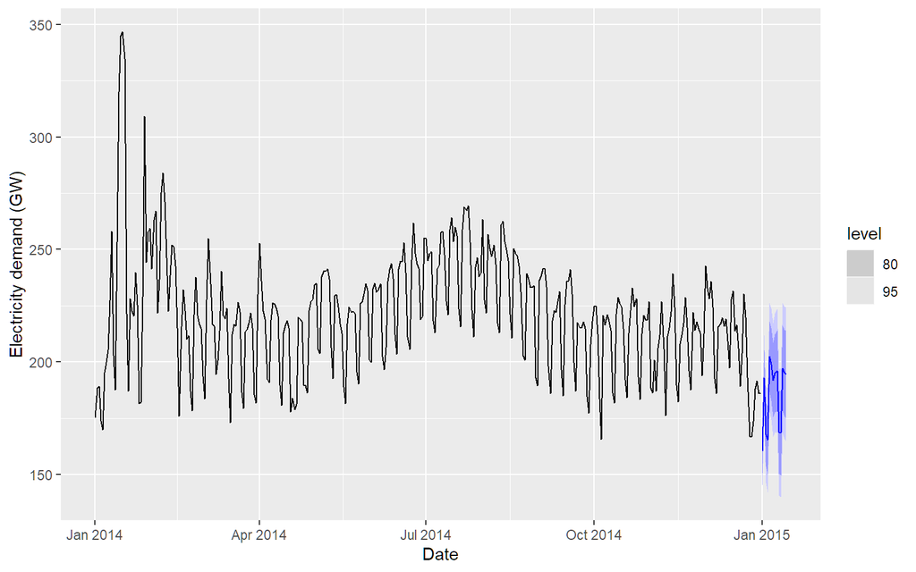

```r
vic_elec_future <- new_data(vic_elec_daily, 14) %>%
  mutate(
    Temperature = 26,
    Temp2 = I(pmax(Temperature - 28.4, 0)),
    Holiday = c(TRUE, rep(FALSE, 13)),
    Day_Type = case_when(
      Holiday ~ "Holiday",
      wday(Date) %in% 2:6 ~ "Weekday",
      TRUE ~ "Weekend"
    )
  )
forecast(elec_model, vic_elec_future) %>%
  autoplot(vic_elec_daily) + labs(y = "Electricity demand (GW)")
```

# fpp3 10.7, Ex 4

> This exercise concerns `aus_accommodation`: the total quarterly takings from accommodation and the room occupancy level for hotels, motels, and guest houses in Australia, between January 1998 and June 2016. Total quarterly takings are in millions of Australian dollars. a. Compute the CPI-adjusted takings and plot the result for each state

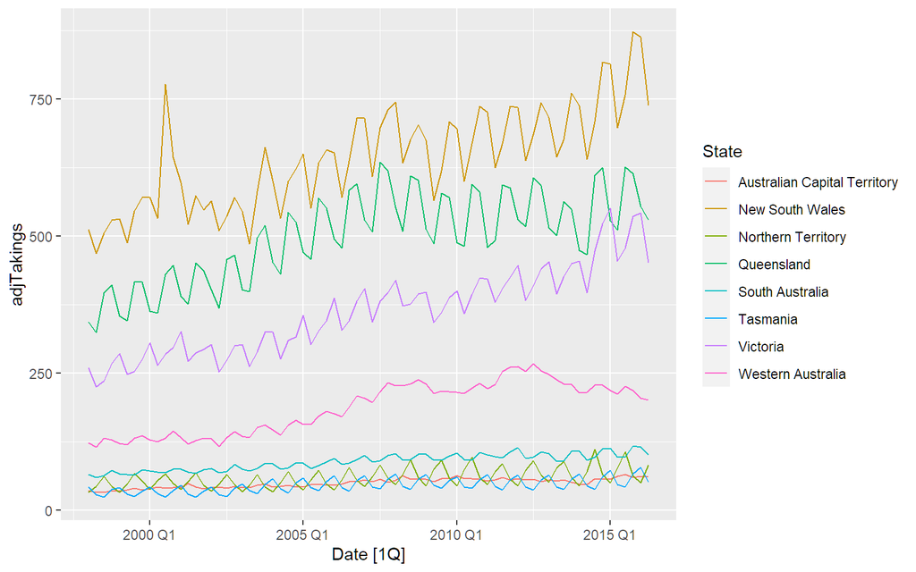

```r
aus_accommodation <- aus_accommodation %>%
  mutate(
    adjTakings = Takings / CPI * 100
  )
aus_accommodation %>%
  autoplot(adjTakings)
```

> 2. For each state, fit a dynamic regression model of CPI-adjusted takings with seasonal dummy variables, a piecewise linear time trend with one knot at 2008 Q1, and ARIMA errors.

```r
fit <- aus_accommodation %>%
  model(
    ARIMA(adjTakings ~ season() + trend(knot = yearquarter("2008 Q1")))
  )
fit
```

```
## # A mable: 8 x 2
## # Key:     State [8]
##   State                        `ARIMA(adjTakings ~ season() + trend(knot = yea~`
##   <chr>                                                                  <model>
## 1 Australian Capital Territory                       <LM w/ ARIMA(1,0,0) errors>
## 2 New South Wales                          <LM w/ ARIMA(1,0,0)(0,0,1)[4] errors>
## 3 Northern Territory                       <LM w/ ARIMA(0,0,1)(1,0,0)[4] errors>
## 4 Queensland                               <LM w/ ARIMA(1,0,0)(0,0,1)[4] errors>
## 5 South Australia                          <LM w/ ARIMA(1,0,0)(1,0,0)[4] errors>
## 6 Tasmania                                 <LM w/ ARIMA(0,0,1)(1,0,0)[4] errors>
## 7 Victoria                                 <LM w/ ARIMA(1,0,0)(0,0,1)[4] errors>
## 8 Western Australia                                  <LM w/ ARIMA(1,0,0) errors>
```

The seasonal dummy variable has not adequately handled the seasonality, so there are seasonal ARIMA components.

> 3. Check that the residuals of the model look like white noise.

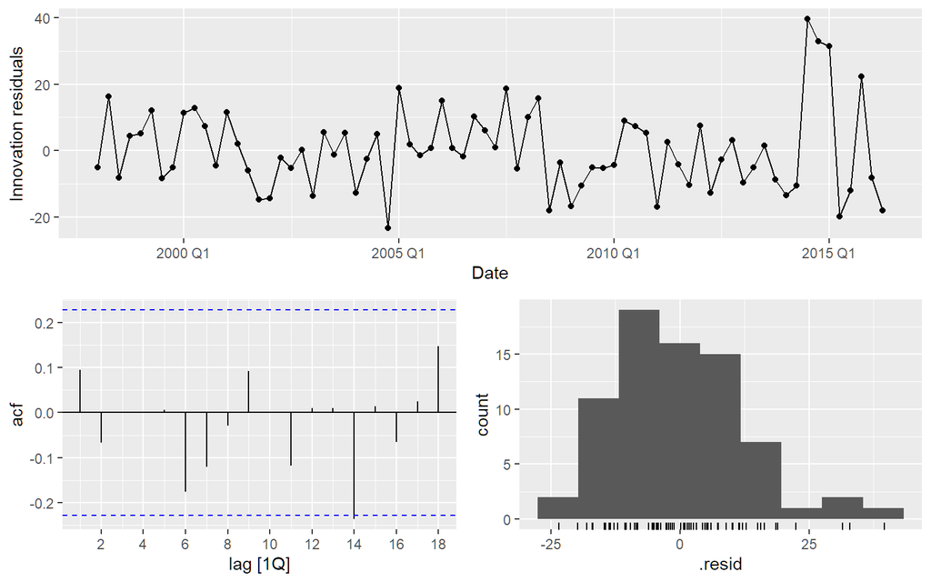

```r
fit %>%
  filter(State == "Victoria") %>%
  gg_tsresiduals()
```

No apparent problems. Similar plots needed for the other states.

> 4. Forecast the takings for each state to the end of 2017. (Hint: You will need to produce forecasts of the CPI first.)

```r
# CPI forecasts
cpif <- aus_accommodation %>%
  model(ARIMA(CPI)) %>%
  forecast(h = 6) %>%
  as_tsibble() %>%
  select(Date, State, CPI = .mean)
fit %>%
  forecast(new_data = cpif) %>%
  mutate(Takings = adjTakings * CPI / 100)
```

```
## # A fable: 48 x 7 [1Q]
## # Key:     State, .model [8]
##    State                    .model    Date   adjTakings .mean   CPI      Takings
##    <chr>                    <chr>    <qtr>       <dist> <dbl> <dbl>       <dist>
##  1 Australian Capital Terr~ "ARIM~ 2016 Q3   N(62, 9.9)  61.6  109.    N(67, 12)
##  2 Australian Capital Terr~ "ARIM~ 2016 Q4    N(59, 12)  58.9  110.    N(65, 15)
##  3 Australian Capital Terr~ "ARIM~ 2017 Q1    N(59, 13)  59.0  110.    N(65, 16)
##  4 Australian Capital Terr~ "ARIM~ 2017 Q2    N(59, 13)  59.4  111.    N(66, 16)
##  5 Australian Capital Terr~ "ARIM~ 2017 Q3    N(61, 13)  60.9  111.    N(68, 16)
##  6 Australian Capital Terr~ "ARIM~ 2017 Q4    N(59, 13)  58.8  112.    N(66, 16)
##  7 New South Wales          "ARIM~ 2016 Q3 N(791, 1254) 791.   109. N(863, 1494)
##  8 New South Wales          "ARIM~ 2016 Q4 N(844, 1589) 844.   110. N(926, 1914)
##  9 New South Wales          "ARIM~ 2017 Q1 N(829, 1679) 829.   110. N(915, 2043)
## 10 New South Wales          "ARIM~ 2017 Q2 N(734, 1703) 734.   111. N(814, 2094)
## # ... with 38 more rows
```

> 5. What sources of uncertainty have not been taken into account in the prediction intervals?
- The uncertainty in the CPI forecasts has been ignored.
- As usual, the estimation of the parameters and the choice of models have also not been accounted for.

# fpp3 10.7, Ex 5

> We fitted a harmonic regression model to part of the `us_gasoline` series in Exercise 6 in Section 7.10. We will now revisit this model, and extend it to include more data and ARMA errors.
> 1. Using `TSLM()`, fit a harmonic regression with a piecewise linear time trend to the full `gasoline` series. Select the position of the knots in the trend and the appropriate number of Fourier terms to include by minimising the AICc or CV value.

Let’s optimize using 2 break points and an unknown number of Fourier terms. Because the number of Fourier terms is integer, we can’t just use `optim`. Instead, we will loop over a large number of possible values for the breakpoints and Fourier terms. There are more than 2000 models fitted here, but `TSLM` is relatively fast.

Note that the possible values of the knots must be restricted so that knot2 is always much larger than knot1. We have set them to be at least 2 years apart here.

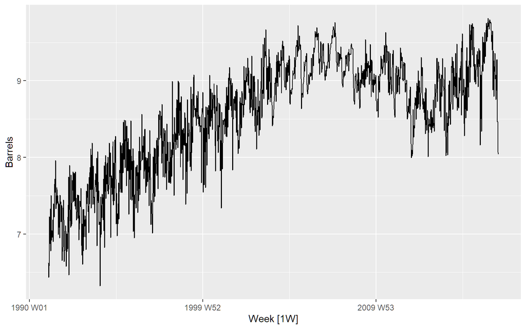

```r
us_gasoline %>% autoplot(Barrels)
```

```r
# Function to compute CV given K and knots.
get_cv <- function(K, knot1, knot2) {
  us_gasoline %>%
    model(TSLM(Barrels ~ fourier(K = K) + trend(c(knot1, knot2)))) %>%
    glance() %>%
    pull(CV)
}

models <- expand.grid(
  K = seq(25),
  knot1 = yearweek(as.character(seq(1991, 2017, 2))),
  knot2 = yearweek(as.character(seq(1991, 2017, 2)))
) %>%
  filter(knot2 - knot1 > 104) %>%
  as_tibble()
models <- models %>%
  mutate(cv = purrr::pmap_dbl(models, get_cv)) %>%
  arrange(cv)

# Best combination
(best <- head(models, 1))
```

```
## # A tibble: 1 x 4
##       K    knot1    knot2     cv
##   <int>   <week>   <week>  <dbl>
## 1     6 2007 W01 2013 W01 0.0641
```

```r
fit <- us_gasoline %>%
  model(
    TSLM(Barrels ~ fourier(K = best$K) + trend(c(best$knot1, best$knot2)))
  )
```

> 2. Now refit the model using `ARIMA()` to allow for correlated errors, keeping the same predictor variables as you used with `TSLM()`.

```r
fit <- us_gasoline %>%
  model(ARIMA(Barrels ~ fourier(K = best$K) + trend(c(best$knot1, best$knot2)) + PDQ(0, 0, 0)))
fit %>% report()
```

```
## Series: Barrels
## Model: LM w/ ARIMA(1,0,1) errors
##
## Coefficients:
##          ar1      ma1  fourier(K = best$K)C1_52  fourier(K = best$K)S1_52
##       0.9277  -0.8414                   -0.1144                   -0.2306
## s.e.  0.0256   0.0357                    0.0133                    0.0132
##       fourier(K = best$K)C2_52  fourier(K = best$K)S2_52
##                         0.0418                    0.0309
## s.e.                    0.0105                    0.0105
##       fourier(K = best$K)C3_52  fourier(K = best$K)S3_52
##                         0.0836                    0.0343
## s.e.                    0.0097                    0.0097
##       fourier(K = best$K)C4_52  fourier(K = best$K)S4_52
##                         0.0187                    0.0399
## s.e.                    0.0094                    0.0094
##       fourier(K = best$K)C5_52  fourier(K = best$K)S5_52
##                        -0.0315                    0.0011
## s.e.                    0.0092                    0.0092
##       fourier(K = best$K)C6_52  fourier(K = best$K)S6_52
##                        -0.0523                    0.0001
## s.e.                    0.0092                    0.0092
##       trend(c(best$knot1, best$knot2))trend
##                                      0.0028
## s.e.                                 0.0001
##       trend(c(best$knot1, best$knot2))trend_831
##                                         -0.0051
## s.e.                                     0.0002
##       trend(c(best$knot1, best$knot2))trend_1144  intercept
##                                           0.0055     7.1065
## s.e.                                      0.0006     0.0352
##
## sigma^2 estimated as 0.06051:  log likelihood=-13.38
## AIC=64.76   AICc=65.33   BIC=163.78
```

> 3. Check the residuals of the final model using the `gg_tsdisplay()` function and a Ljung-Box test. Do they look sufficiently like white noise to continue? If not, try modifying your model, or removing the first few years of data.

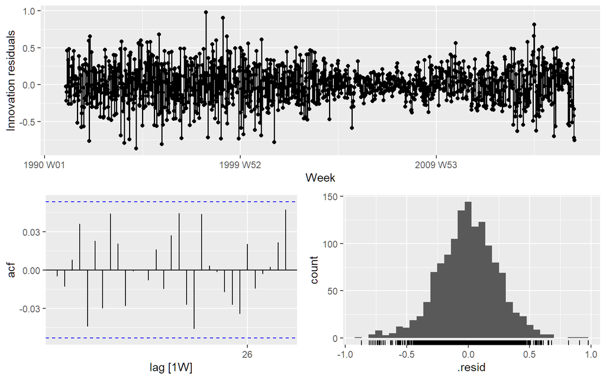

```r
gg_tsresiduals(fit)
```

```r
augment(fit) %>% features(.innov, ljung_box, dof = 18, lag = 24)
```

```
## # A tibble: 1 x 3
##   .model                                                       lb_stat lb_pvalue
##   <chr>                                                          <dbl>     <dbl>
## 1 "ARIMA(Barrels ~ fourier(K = best$K) + trend(c(best$knot1, ~    23.6  0.000623
```

The model looks pretty good, although there is some heteroskedasticity and the model fails the Ljung-Box test. Nevertheless, the residual autocorrelations are tiny so should have almost no effect.

> 4. Once you have a model with white noise residuals, produce forecasts for the next year.

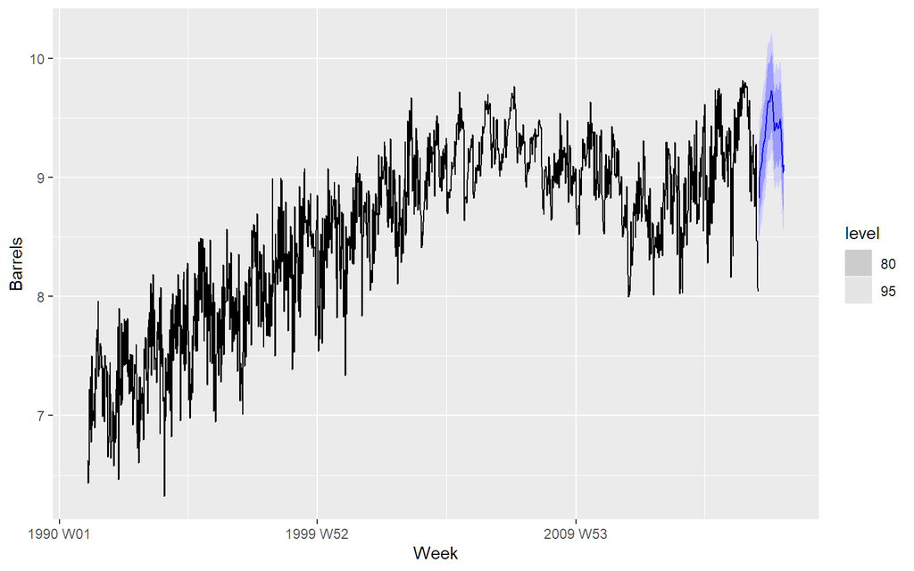

```r
fit %>%
  forecast(h = "1 year") %>%
  autoplot(us_gasoline)
```

# fpp3 10.7, Ex 6

> Electricity consumption is often modelled as a function of temperature. Temperature is measured by daily heating degrees and cooling degrees. Heating degrees is $18^\circ$C minus the average daily temperature when the daily average is below $18^\circ$C; otherwise it is zero. This provides a measure of our need to heat ourselves as temperature falls. Cooling degrees measures our need to cool ourselves as the temperature rises. It is defined as the average daily temperature minus $18^\circ$C when the daily average is above $18^\circ$C; otherwise it is zero. Let $y_t$ denote the monthly total of kilowatt-hours of electricity used, let $x_{1,t}$ denote the monthly total of heating degrees, and let $x_{2,t}$ denote the monthly total of cooling degrees.

> An analyst fits the following model to a set of such data:
> $$y^*_t = \beta_1x^*_{1,t} + \beta_2x^*_{2,t} + \eta_t,$$
> where
> $$(1-\Phi_{1}B^{12} - \Phi_{2}B^{24})(1-B)(1-B^{12})\eta_t = (1+\theta_1 B)\varepsilon_t$$
> and $y^*_t = \log(y_t)$, $x^*_{1,t} = \sqrt{x_{1,t}}$ and $x^*_{2,t}=\sqrt{x_{2,t}}$.
> 1. What sort of ARIMA model is identified for $\eta_t$?

ARIMA(0,1,1)(2,1,0)$_{12}$

> 2. The estimated coefficients are

> | Parameter | Estimate | s.e. | $Z$ | $P$-value |
> | --- | --- | --- | --- | --- |
> | $\beta_1$ | 0.0077 | 0.0015 | 4.98 | 0.000 |
> | $\beta_2$ | 0.0208 | 0.0023 | 9.23 | 0.000 |
> | $\theta_1$ | 0.5830 | 0.0720 | 8.10 | 0.000 |
> | $\Phi_{1}$ | -0.5373 | 0.0856 | -6.27 | 0.000 |
> | $\Phi_{2}$ | -0.4667 | 0.0862 | -5.41 | 0.000 |

> Explain what the estimates of $\beta_1$ and $\beta_2$ tell us about electricity consumption.

$b_1$ is the unit increase in $y_t^*$ when $x_{1,t}^*$ increases by 1. This is a little hard to interpret, but it is clear that monthly total electricity usage goes up when monthly heating degrees goes up. Similarly, for $b_2$, monthly total electricty usage goes up when monthly cooling degrees goes up.

> 3. Write the equation in a form more suitable for forecasting.

This turned out to be way more messy than I expected, but for what it’s worth, here it is in all its ugliness.

First apply the differences to the regression equation.
$$(1-B)(1-B^{12}) y_t^* = b_1^*(1-B)(1-B^{12})x_{1,t}^* + b_2^*(1-B)(1-B^{12})x_{2,t}^* + (1-B)(1-B^{12})\eta_{t}$$
So
$$\begin{align*}
(y^*_{t} - y^*_{t-1} - y^*_{t-12} +y^*_{t-13})
=& b_1(x^*_{1,t} - x^*_{1,t-1} - x^*_{1,t-12} + x^*_{1,t-13})
+ b_2(x^*_{2,t} - x^*_{2,t-1} - x^*_{2,t-12} + x^*_{2,t-13}) + \eta'_t
\end{align*}$$
Multiplying by the AR polynomial gives
$$\begin{align*}
(y^*_{t} & - y^*_{t-1} - y^*_{t-12} +y^*_{t-13})
-\Phi_{1}(y^*_{t-12} - y^*_{t-13} - y^*_{t-24} +y^*_{t-25})
-\Phi_{2}(y^*_{t-24} - y^*_{t-25} - y^*_{t-36} +y^*_{t-37})\\
= & b_1(x^*_{1,t} - x^*_{1,t-1} - x^*_{1,t-12} + x^*_{1,t-13})
-\Phi_{1}b_1(x^*_{1,t-12} - x^*_{1,t-13} - x^*_{1,t-24} + x^*_{1,t-25})
-\Phi_{2}b_1(x^*_{1,t-24} - x^*_{1,t-25} - x^*_{1,t-36} + x^*_{1,t-37}) \\
& + b_2(x^*_{2,t} - x^*_{2,t-1} - x^*_{2,t-12} + x^*_{2,t-13})
- \Phi_{1}b_2(x^*_{2,t-12} - x^*_{2,t-13} - x^*_{2,t-24} + x^*_{2,t-25})
- \Phi_{2}b_2(x^*_{2,t-24} - x^*_{2,t-25} - x^*_{2,t-36} + x^*_{2,t-37}) \\
& + \varepsilon_t - \theta_1 \varepsilon_{t-1}.
\end{align*}$$
Finally, we move all but $y_t^*$ to the right hand side:
$$\begin{align*}
y^*_{t} = & y^*_{t-1} + y^*_{t-12} - y^*_{t-13}
+\Phi_{1}(y^*_{t-12} - y^*_{t-13} - y^*_{t-24} +y^*_{t-25})
+\Phi_{2}(y^*_{t-24} - y^*_{t-25} - y^*_{t-36} +y^*_{t-37})\\
& + b_1(x^*_{1,t} - x^*_{1,t-1} - x^*_{1,t-12} + x^*_{1,t-13})
-\Phi_{1}b_1(x^*_{1,t-12} - x^*_{1,t-13} - x^*_{1,t-24} + x^*_{1,t-25})
-\Phi_{2}b_1(x^*_{1,t-24} - x^*_{1,t-25} - x^*_{1,t-36} + x^*_{1,t-37}) \\
& + b_2(x^*_{2,t} - x^*_{2,t-1} - x^*_{2,t-12} + x^*_{2,t-13})
- \Phi_{1}b_2(x^*_{2,t-12} - x^*_{2,t-13} - x^*_{2,t-24} + x^*_{2,t-25})
- \Phi_{2}b_2(x^*_{2,t-24} - x^*_{2,t-25} - x^*_{2,t-36} + x^*_{2,t-37}) \\
& + \varepsilon_t - \theta_1 \varepsilon_{t-1}.
\end{align*}$$

> 4. Describe how this model could be used to forecast electricity demand for the next 12 months.

For $t=T+1$, we use the above equation to find a point forecast of $y_{T+1}^*$, setting $\varepsilon_{T+1}=0$ and $\hat{\varepsilon}_T$ to the last residual. The actual $y_t^*$ values are all known, as are all the $x_{1,t}^*$ and $x_{2,t}^*$ values up to time $t=T$. For $x_{1,T+1}^*$ and $x_{2,T+1}^*$, we could use a forecast (for example, a seasonal naive forecast).

For $t=T+2,\dots,T+12$, we do something similar, but both $\varepsilon$ values are set to 0 and $y^*_{T+k}$ ($k\ge1$) is replaced by the forecasts just calculated.

> 5. Explain why the $\eta_t$ term should be modelled with an ARIMA model rather than modelling the data using a standard regression package. In your discussion, comment on the properties of the estimates, the validity of the standard regression results, and the importance of the $\eta_t$ model in producing forecasts.
- The non-stationarity of $\eta_t$ means the coefficients in the regression model will be inconsistent if OLS is used.
- The standard errors will be incorrectly computed.
- Which means all the p-values will be wrong.
- Using an ARIMA structure for $\eta_t$ allows these problems to be corrected, plus the short-term forecasts will be more accurate.